# Data visualizations and know-hows

<Kaitlyn Watson Group 9>

M3 ICA3

# 1 The data

For this section we will use the `nfl` data. We will use the `tidyverse` and `ggiraph` packages. You will need to first install `ggiraph` with `install.packages("ggiraph")`.

```r
library(tidyverse)
library(ggplot2)
library(ggiraph)
```

**Do any interesting relationships exists between NFL combine metrics and draft position?**

Not all players have a draft position and not all NFL players have stats in the combine.

Below is data on every player who participated in the 2018 NFL draft combine or was drafted by an NFL team in 2018. Let’s read in the data and set it as a tibble to make it easier to view. The argument `stringsAsFactors = FALSE` ensures variables such as `Player`, `Pos`, `School`, etc are read in as type character.

| Player | Pos | School | Ht | Wt | Dash40 | Vertical | Bench | Broad.Jump | Cone3 | Shuttle | Team | Round | Pick |
| --- | --- | --- | --- | --- | --- | --- | --- | --- | --- | --- | --- | --- | --- |
| Dante Pettis | WR | Washington | 73 | 186 | NA | NA | NA | NA | NA | NA | San Francisco 49ers | 2 | 44 |
| Kemoko Turay | EDGE | Rutgers | 77 | 253 | 4.65 | NA | NA | NA | NA | NA | Indianapolis Colts | 2 | 52 |
| Josh Adams | RB | Notre Dame | 74 | 213 | NA | NA | 18 | NA | NA | NA | NA | 0 | 0 |
| Ola Adeniyi | EDGE | Toledo | 74 | 248 | 4.83 | 31.5 | 26 | NA | 7.21 | 4.28 | NA | 0 | 0 |
| Jordan Akins | TE | Central Florida | 75 | 249 | NA | NA | NA | NA | NA | NA | Houston Texans | 3 | 98 |
| Jaire Alexander | CB | Louisville | 71 | 192 | 4.38 | 35.0 | 14 | 127 | 6.71 | 3.98 | Green Bay Packers | 1 | 18 |
| Austin Allen | QB | Arkansas | 73 | 210 | 4.81 | 29.5 | NA | 112 | 7.18 | 4.48 | NA | 0 | 0 |
| Brian Allen | C | Michigan St. | 73 | 298 | 5.34 | 26.5 | 27 | 99 | 7.81 | 4.71 | Los Angeles Rams | 4 | 111 |
| Josh Allen | QB | Wyoming | 77 | 237 | 4.75 | 33.5 | NA | 119 | 6.90 | 4.40 | Buffalo Bills | 1 | 7 |
| Marcus Allen | S | Penn St. | 74 | 202 | NA | 37.0 | 15 | 127 | NA | 4.32 | NA | 0 | 0 |

[output cut: 326 more lines]

- **Player**: player’s name
- **Pos**: player’s position
- **School**: college of player
- **Ht**: height in inches
- **Wt**: weight in pounds
- **Dash40**: forty yard dash time in seconds
- **Vertical**: vertical jump in inches
- **Bench**: number of bench press repititions at 225lbs
- **Broad.Jump**: broad jump distance in inches
- **Cone3**: 3 cone drill time in seconds
- **Shuttle**: twenty yard shuttle time in seconds
- **Team**: team that drafted the player
- **Round**: round the player was drafted (0 means no round)
- **Pick**: draft selection (0 means not drafted)

# 2 Investigation

As you can see above, `nfl` contains a lot of missing values - represented by `NA`. Not all players participate in the NFL combine, and some who do participate do not perform each skills test. Also, undrafted players have `NA` values for their `Team`. Before we create visualizations let’s try to better understand some of the data.

## 2.1 Exercises

1. How many players went undrafted in the data set `nfl`?

```r
undrafted<-nfl %>%
  filter(Pick==0)
count(undrafted)
```

| n |
| --- |
| 184 |

2. Which player had the fastest 40 yard dash time? What was his time?

```r
nfl %>%
  select(Player, Dash40) %>%
  arrange(Dash40, na.rm=TRUE)
```

| Player | Dash40 |
| --- | --- |
| Donte Jackson | 4.32 |
| Parry Nickerson | 4.32 |
| Denzel Ward | 4.32 |
| Troy Apke | 4.34 |
| D.J. Chark | 4.34 |
| Tony Brown | 4.35 |
| Anthony Averett | 4.36 |
| Marquez Valdes-Scantling | 4.37 |
| Jaire Alexander | 4.38 |
| Shaquem Griffin | 4.38 |

[output cut: 326 more lines]

Denzel Ward, Donte Jackson, Parry Nickerson have 4.32 as the fastest time.

3. How many players are in the data set for each position? *Hint*: `table()`

```r
nfl %>%
  arrange((Pos)) %>%
  count(Pos)
```

| Pos | n |
| --- | --- |
| C | 9 |
| CB | 41 |
| DB | 2 |
| DE | 16 |
| DT | 24 |
| EDGE | 23 |
| FB | 1 |
| ILB | 15 |
| K | 4 |
| LB | 3 |

[output cut: 11 more lines]

4. What was the mean number of bench press repititions for all players listed at the position of `DT`?

```r
nfl %>%
  filter(Pos=="DT") %>%
  summarise(mean(Bench, na.rm=TRUE))
```

| mean(Bench, na.rm = TRUE) |
| --- |
| 28.82353 |

5. Which team drafted the most players in 2018?

```r
nfl %>%
  count((Team)) %>%
  arrange(desc(n))
```

| (Team) | n |
| --- | --- |
| NA | 184 |
| Denver Broncos | 9 |
| Cincinnati Bengals | 8 |
| Baltimore Ravens | 7 |
| Indianapolis Colts | 7 |
| Carolina Panthers | 6 |
| Cleveland Browns | 6 |
| Los Angeles Chargers | 6 |
| Los Angeles Rams | 6 |
| New England Patriots | 6 |

[output cut: 23 more lines]

Denver Broncos drafted 9 players

# 3 Visualizations with ggplot

## 3.1 Exercises

Recreate plots 1 - 5. Add comments to the code that generated plots 6 and 7 to explain what is being done in those plots. Use the available hints before looking at the solution. Comment on any interesting trends/relationships you observe.

### Plot 1

#### Plot

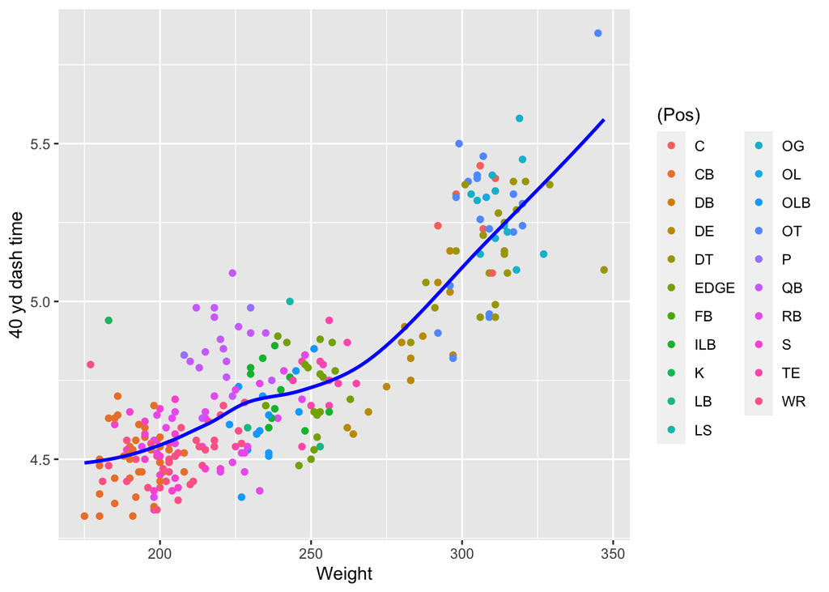

#### Hints

- `geom point()`
- `geom_smooth()`

### Plot 2

#### Plot

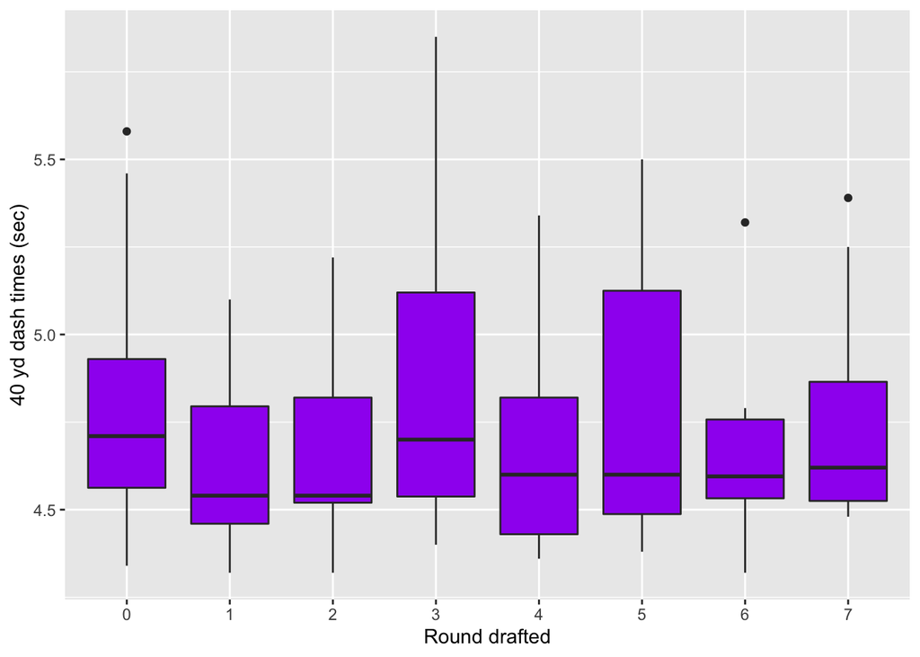

#### Hints

- `geom_boxplot`
- colors used: purple, black
- `caption` argument in `labs()`

### Plot 3

#### Plot

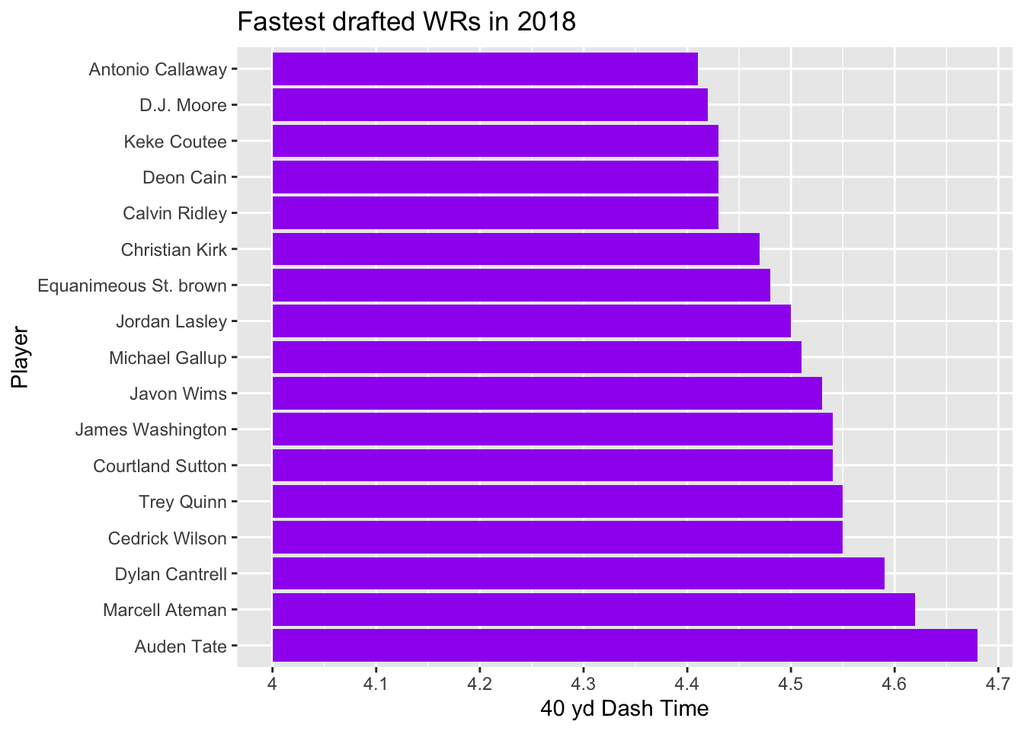

#### Hints

- subset `nfl` to create a data frame with only WR who were drafted
- colors used: purple, black
- `stat = "identity"` in `geom_bar()`
- flip coordinates
- `scale_y_continuous(breaks = seq(0, 1, .1), labels = seq((4, 5), .1))`
- to sort the bars use `reorder(Player, -Dash40)`

### Plot 4

#### Plot

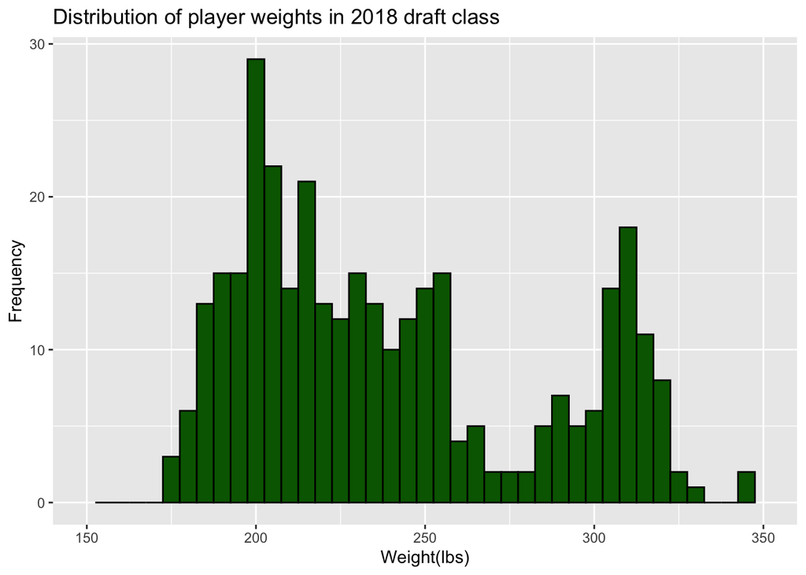

#### Hints

- `geom_histogram`
- colors used: darkgreen, black
- `binwidth = 5`

### Plot 5

#### Plot

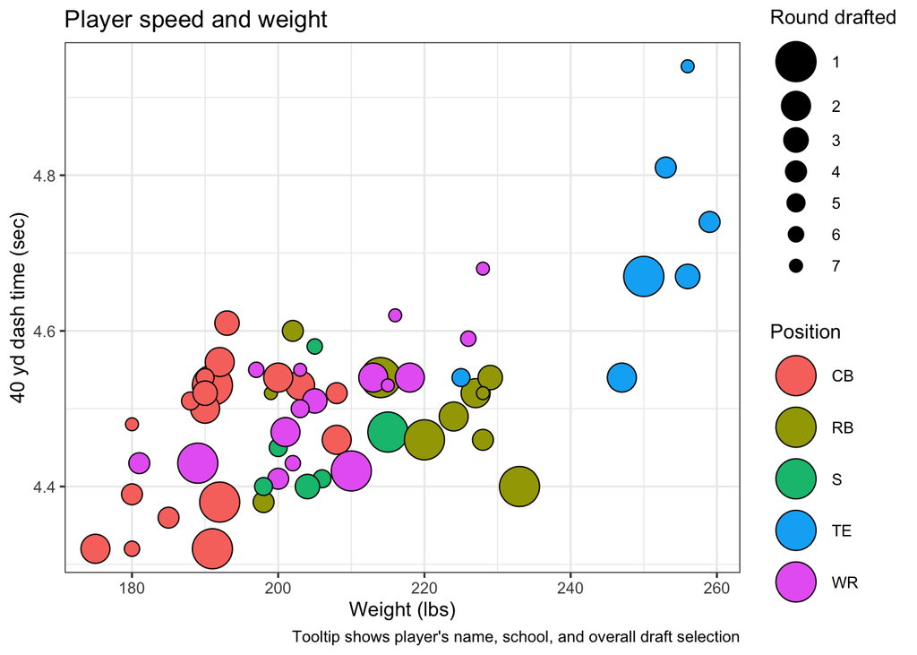

#### Hints

- subset `nfl` to only include the positions of CB, S, RB, WR, and TE for players that were drafted
- color used: black
- `shape = 21`
- `scale_size(range=c(10, 3))`
- `theme_bw()`

### Plot 6

#### Plot

[interactive chart not shown]

### Plot 7

#### Plot

[interactive chart not shown]

Plot 7 is relatively the same information in regards to Plot 6. However, when hovering over one of the circles on the graph, all other circles of the same size highlight black as well. This is representing all the players who got picked in the same draft round. Looking up at the code above, it seems that by adding girafe_options to the code allows the option to hover and fill black. Additionally, there are several points within the code where the draft is overridden.

# 4 Data know hows

In this section, we will get some practice reading in data sets and working with the apply function.

## 4.1 Read data

Data may be

1. available in base R or through an R package such as the `diamonds` data set that is available through `tidyverse`;
2. read in to R from a file on your computer;
3. read in to R directly from a website;
4. scraped from a website.

Today we will get practice with examples that involve 2 and 3. Some of the most popular R functions to accomplish this are

- `read.table()`
- `read.csv()`
- `load()`

### 4.1.1 Exercises

Read in the following data sets and save them as a well-named R object. A preview of each data set is given below for you to check your answer. Make sure all variable types are the same, headers are available when applicable, and `NA` values appear where appropriate.

1. `nevada_casino_sqft.csv` (available on D2L)

```r
Nevada_Casino<-read.csv("nevada_casino_sqft.csv", na.strings = "")
head(Nevada_Casino)
```

|  | COUNTY | AREA | NAME | PITGAMES | SLOTS | KENO | BINGO | SPORTS | POKER | TOTAL |
| --- | --- | --- | --- | --- | --- | --- | --- | --- | --- | --- |
| 1 | 14 | 0 | ALAMO CASINO - MILL CITY | 0 | 3500 | 0 | 0 | 0 | 0 | 3500 |
| 2 | 4 | 0 | ALAMO CASINO AT WELLS PETRO | 0 | 2250 | 0 | NA | 0 | 0 | NA |
| 3 | 16 | 2 | ALAMO TRAVEL CENTER | 900 | 6100 | 0 | 0 | 0 | 150 | 7150 |
| 4 | 2 | 0 | ALBERTSON'S #6046 | 0 | 400 | 0 | 0 | 0 | 0 | 400 |
| 5 | 2 | 3 | ALIANTE CASINO + HOTEL | 5060 | 98007 | 0 | 5624 | 14200 | 2109 | 125000 |
| 6 | 2 | 4 | AQUARIUS CASINO RESORT | 8215 | 42075 | 1680 | 0 | 5100 | 0 | 57070 |

|  | COUNTY | AREA | NAME | PITGAMES | SLOTS | KENO | BINGO | SPORTS | POKER | TOTAL |
| --- | --- | --- | --- | --- | --- | --- | --- | --- | --- | --- |
| 1 | 14 | 0 | ALAMO CASINO - MILL CITY | 0 | 3500 | 0 | 0 | 0 | 0 | 3500 |
| 2 | 4 | 0 | ALAMO CASINO AT WELLS PETRO | 0 | 2250 | 0 | NA | 0 | 0 | NA |
| 3 | 16 | 2 | ALAMO TRAVEL CENTER | 900 | 6100 | 0 | 0 | 0 | 150 | 7150 |
| 4 | 2 | 0 | ALBERTSON'S #6046 | 0 | 400 | 0 | 0 | 0 | 0 | 400 |
| 5 | 2 | 3 | ALIANTE CASINO + HOTEL | 5060 | 98007 | 0 | 5624 | 14200 | 2109 | 125000 |
| 6 | 2 | 4 | AQUARIUS CASINO RESORT | 8215 | 42075 | 1680 | 0 | 5100 | 0 | 57070 |

2. `nevada_casino_sqft.csv` (available at: http://www.stat.ufl.edu/~winner/data/nevada_casino_sqft.csv)

```r
Nevada_Casino2<-read.csv("http://www.stat.ufl.edu/~winner/data/nevada_casino_sqft.csv", stringsAsFactors = FALSE)
head(Nevada_Casino2)
```

|  | COUNTY | AREA | NAME | PITGAMES | SLOTS | KENO | BINGO | SPORTS | POKER | TOTAL |
| --- | --- | --- | --- | --- | --- | --- | --- | --- | --- | --- |
| 1 | 14 | 0 | ALAMO CASINO - MILL CITY | 0 | 3500 | 0 | 0 | 0 | 0 | 3500 |
| 2 | 4 | 0 | ALAMO CASINO AT WELLS PETRO | 0 | 2250 | 0 | 0 | 0 | 0 | 2250 |
| 3 | 16 | 2 | ALAMO TRAVEL CENTER | 900 | 6100 | 0 | 0 | 0 | 150 | 7150 |
| 4 | 2 | 0 | ALBERTSON'S #6046 | 0 | 400 | 0 | 0 | 0 | 0 | 400 |
| 5 | 2 | 3 | ALIANTE CASINO + HOTEL | 5060 | 98007 | 0 | 5624 | 14200 | 2109 | 125000 |
| 6 | 2 | 4 | AQUARIUS CASINO RESORT | 8215 | 42075 | 1680 | 0 | 5100 | 0 | 57070 |

|  | COUNTY | AREA | NAME | PITGAMES | SLOTS | KENO | BINGO | SPORTS | POKER | TOTAL |
| --- | --- | --- | --- | --- | --- | --- | --- | --- | --- | --- |
| 1 | 14 | 0 | ALAMO CASINO - MILL CITY | 0 | 3500 | 0 | 0 | 0 | 0 | 3500 |
| 2 | 4 | 0 | ALAMO CASINO AT WELLS PETRO | 0 | 2250 | 0 | 0 | 0 | 0 | 2250 |
| 3 | 16 | 2 | ALAMO TRAVEL CENTER | 900 | 6100 | 0 | 0 | 0 | 150 | 7150 |
| 4 | 2 | 0 | ALBERTSON'S #6046 | 0 | 400 | 0 | 0 | 0 | 0 | 400 |
| 5 | 2 | 3 | ALIANTE CASINO + HOTEL | 5060 | 98007 | 0 | 5624 | 14200 | 2109 | 125000 |
| 6 | 2 | 4 | AQUARIUS CASINO RESORT | 8215 | 42075 | 1680 | 0 | 5100 | 0 | 57070 |

3. `qqq.tsv` (available on D2L)

```r
QQQ<-read.csv("qqq.tsv", header=TRUE, sep="\t")
head(QQQ)
```

|  | QQQ.Open | QQQ.High | QQQ.Low | QQQ.Close | QQQ.Volume | QQQ.Adjusted |
| --- | --- | --- | --- | --- | --- | --- |
| 1 | 43.46 | 44.06 | 42.52 | 43.24 | 167689500 | 38.79258 |
| 2 | 43.30 | 44.21 | 43.15 | 44.06 | 136853500 | 39.52824 |
| 3 | 43.95 | 43.95 | 43.48 | 43.85 | 138958800 | 39.33984 |
| 4 | 43.89 | 44.12 | 43.64 | 43.88 | 106401600 | 39.36676 |
| 5 | 44.01 | 44.29 | 43.63 | 44.10 | 121577500 | 39.56412 |
| 6 | 43.96 | 44.66 | 43.82 | 44.62 | 121070100 | 40.03062 |

|  | QQQ.Open | QQQ.High | QQQ.Low | QQQ.Close | QQQ.Volume | QQQ.Adjusted |
| --- | --- | --- | --- | --- | --- | --- |
| 1 | 43.46 | 44.06 | 42.52 | 43.24 | 167689500 | 38.79258 |
| 2 | 43.30 | 44.21 | 43.15 | 44.06 | 136853500 | 39.52824 |
| 3 | 43.95 | 43.95 | 43.48 | 43.85 | 138958800 | 39.33984 |
| 4 | 43.89 | 44.12 | 43.64 | 43.88 | 106401600 | 39.36676 |
| 5 | 44.01 | 44.29 | 43.63 | 44.10 | 121577500 | 39.56412 |
| 6 | 43.96 | 44.66 | 43.82 | 44.62 | 121070100 | 40.03062 |

4. `spy.txt` (available on D2L)

```r
Spy<-read.table("spy.txt", header = FALSE, sep = "@")
head(Spy)
```

|  | V1 | V2 | V3 | V4 | V5 | V6 | V7 |
| --- | --- | --- | --- | --- | --- | --- | --- |
| 1 | 1 | 142.25 | 142.86 | 140.57 | 141.37 | 94807600 | 110.5206 |
| 2 | 2 | 141.23 | 142.05 | 140.61 | 141.67 | 69620600 | 110.7551 |
| 3 | 3 | 141.33 | 141.40 | 140.38 | 140.54 | 76645300 | 109.8717 |
| 4 | 4 | 140.82 | 141.41 | 140.25 | 141.19 | 71655000 | 110.3799 |
| 5 | 5 | 141.31 | 141.60 | 140.40 | 141.07 | 75680100 | 110.2861 |
| 6 | 6 | 140.58 | 141.57 | 140.30 | 141.54 | 72428000 | 110.6535 |

|  | V1 | V2 | V3 | V4 | V5 | V6 | V7 |
| --- | --- | --- | --- | --- | --- | --- | --- |
| 1 | 1 | 142.25 | 142.86 | 140.57 | 141.37 | 94807600 | 110.5206 |
| 2 | 2 | 141.23 | 142.05 | 140.61 | 141.67 | 69620600 | 110.7551 |
| 3 | 3 | 141.33 | 141.40 | 140.38 | 140.54 | 76645300 | 109.8717 |
| 4 | 4 | 140.82 | 141.41 | 140.25 | 141.19 | 71655000 | 110.3799 |
| 5 | 5 | 141.31 | 141.60 | 140.40 | 141.07 | 75680100 | 110.2861 |
| 6 | 6 | 140.58 | 141.57 | 140.30 | 141.54 | 72428000 | 110.6535 |

## 4.2 Apply

### 4.2.1 Matrix examples

The examples below can also be applied to data frames

```r
# create a 3 x 3 matrix
my.matrix <- matrix(data = c(3, 5, 10, -1, 0, 2, 18, 5, -3),
                    nrow = 3, ncol = 3)

# matrix is filled column-wise, view matrix
my.matrix

# by columns
apply(X = my.matrix, MARGIN = 2, FUN = mean)
apply(X = my.matrix, MARGIN = 2, FUN = max)

# by rows
apply(X = my.matrix, MARGIN = 1, FUN = sd)
apply(X = my.matrix, MARGIN = 1, FUN = which.max)
apply(X = my.matrix, MARGIN = 1, FUN = sort)
```

```r
# create a 4 x 3 matrix
Kaitlyn_matrix <- matrix(data = c(1, 2, 3, 4, 5, 6, 7, 8, 9, 10, 11, 12),
                    nrow = 4, ncol = 3)
Kaitlyn_matrix
```

```
     [,1] [,2] [,3]
[1,]    1    5    9
[2,]    2    6   10
[3,]    3    7   11
[4,]    4    8   12
```

```r
apply(X = Kaitlyn_matrix, MARGIN = 1, FUN = which.max)
```

```
[1] 3 3 3 3
```

2. Explain what the which.max function is doing.

It is telling us the location of the very first maximum number with is in the column 3

### 4.2.2 Array examples

```r
# create a 2 x 2 x 3 array that contains the numbers 1 - 12
my.array <- array(data = c(1:12), dim = c(2,2,3))

# view the array
my.array

# apply sum over 1 dimension
apply(my.array, 1, sum)
apply(my.array, 2, sum)
apply(my.array, 3, sum)

# apply sum over multiple dimensions
apply(my.array, c(1,2), sum)
apply(my.array, c(1,3), sum)
apply(my.array, c(2,3), sum)
apply(my.array, c(3,1), sum)
apply(my.array, c(3,2), sum)
```

## 4.3 Further details

A summary of the `a,l,s,t apply` functions

| Command | Description |
| --- | --- |
| `apply(X, MARGIN, FUN, ...)` | Obtain a vector/array/list by applying `FUN` along the specified `MARGIN` of an array or matrix `X` |
| `lapply(X, FUN, ...)` | Obtain a list by applying `FUN` to the elements of a list `X` |
| `sapply(X, FUN, ...)` | Simplified version of `lapply`. Returns a vector/array instead of list. |
| `tapply(X, INDEX, FUN, ...)` | Obtain a table by applying `FUN` to each combination of the factors given in `INDEX` |

- The above functions are good alternatives to loops
- They are typically more efficient than loops (often run considerably faster on large data sets)
- They take practice to get used to, but make analysis easier to debug and less prone to error when used effectively
- Look at the Help’s examples

# 5 References

1. https://www.pro-football-reference.com/draft/2018-combine.htm
2. http://r-statistics.co/Top50-Ggplot2-Visualizations-MasterList-R-Code.htm
3. http://www.ggplot2-exts.org/ggiraph.html
4. https://davidgohel.github.io/ggiraph/articles/offcran/using_ggiraph.html